# Statistical Methods for Reliability Data

Chapter 1 - Reliability Concepts and Reliability Data

W. Q. Meeker, L. A. Escobar, and J. K. Freels

29 June 2018

# CHAPTER OVERVIEW

## This chapter explains...

- Basic ideas behind product reliability
- Reasons for collecting reliability data
- Distinguishing features of reliability data
- General models for reliability data
- Examples of reliability data and motivations for collecting the data
- A general strategy used for data analysis, modeling, and inference from reliability data

# 1.1.1 - Quality And Reliability

## What is reliability?

- A stochastic measure of the likelihood that a component or system will perform its required function(s) for a specified period of operation under stated operating conditions
  - Stochastic - The true measure of the likelihood is random/uncertain due to complex factors affecting how long a given system will survive
  - Required function(s) - Systems perform many functions - the function of interest must be specifically defined
  - Period of operation - Operating life may be accumulated on a continuous scale (time, distance) or a discrete scale (shots, launches, take-off/landing cycles)
  - Operating conditions - Harsh environments may consume operating life more quickly than benign environments - therefore a system's operating environment must be defined

## What is quality?

- How well a population of manufactured products conform to the initial design requirements and specifications
  - A product can have BOTH high quality AND low reliability
  - This highlights the importance of developing good reliability requirements early on in a program

## What is maintainability?

- The probability that an unavailable or degraded function can be restored to a specified condition within a period of time when maintenance is performed in accordance with prescribed procedures

## What is availability?

- The probability repairable that a component or system can perform a required function at a given point in time when used under stated operating conditions

## What is reliability engineering?

- Academic discipline focused on the analysis, characterization, and measurement of system failures to increase system design life and improve system availability by:
  - Eliminating and/or reducing the likelihood of failures and safety risks
  - Reducing downtime due to maintenance
  - Merging many statistical and engineering disciplines together

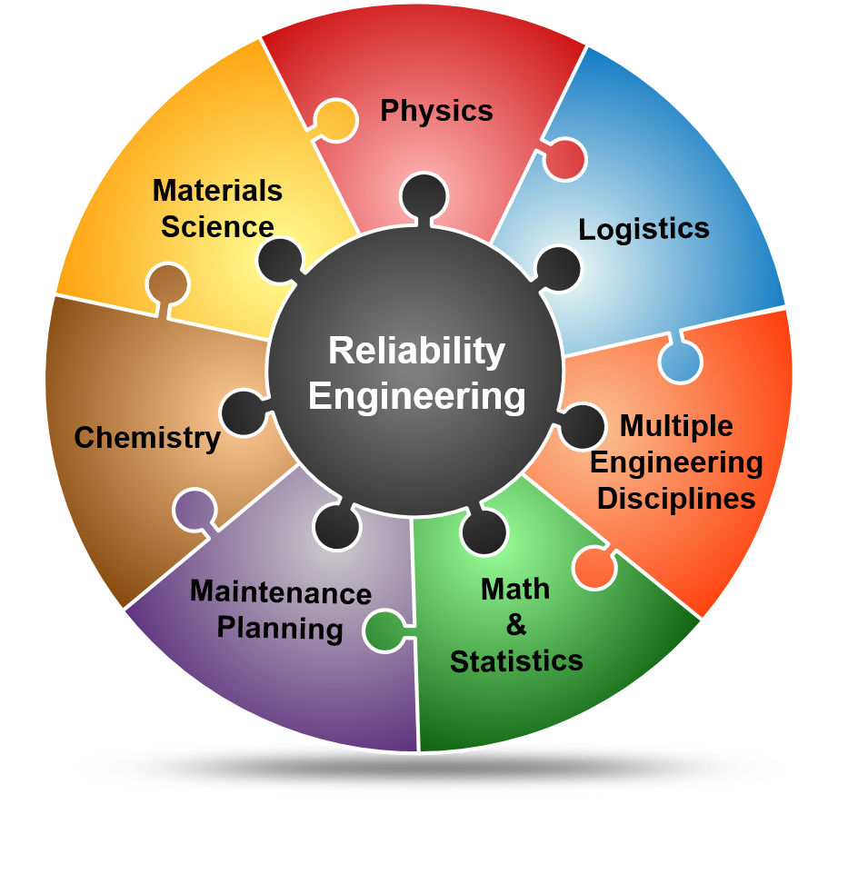

> ...is engineering in its most practical form... James R. Schlesinger U.S. Secretary of Defense (1973-1975)

## Why study reliability?

- Ever-increasing system complexity and sophistication
- Public awareness and insistence on product reliability
- Profit considerations resulting from the high cost of failures, repairs, and warranty programs
- Contractual requirements to meet reliability and maintainability performance specifications
- Laws and regulations concerning product liability and safety
  - Food and Drug Act
  - Flammable Fabrics Act
  - Federal Hazardous Substance Act
  - National Traffic and Motor Vehicle Safety Act
  - Fire Research and Safety Act
  - Child Protection and Toy Safety Act
  - Poison Prevention Packaging Act
  - Occupational Safety and Health Act
  - Federal Boat Safety Act
  - Consumer Product Safety Act

## Approaches to meeting reliability requirements

- Engineering (deterministic) approach
  - Prevent failures by designing in a safety factor of 4 to 10 times the expected average stress
  - Can result in overdesigned products leading to dramatically increased costs
  - Can also result in under-designed products if an unanticipated load or a material weakness results in a failure
- Probabilistic approach
  - Treats failures as random events
  - In theory, if we understood the exact physics and chemistry of a failure process, many failures of a component could be predicted with certainty
  - With limited data on the state of a component, and incomplete knowledge of the processes that cause failures, failures will appear to occur at random over time
  - This random process may exhibit a pattern which can be modeled by some probability distribution

## The product reliability environment

- Consumers & producers often have different priorities when it comes to product reliability
- However, both usually work hard to save money

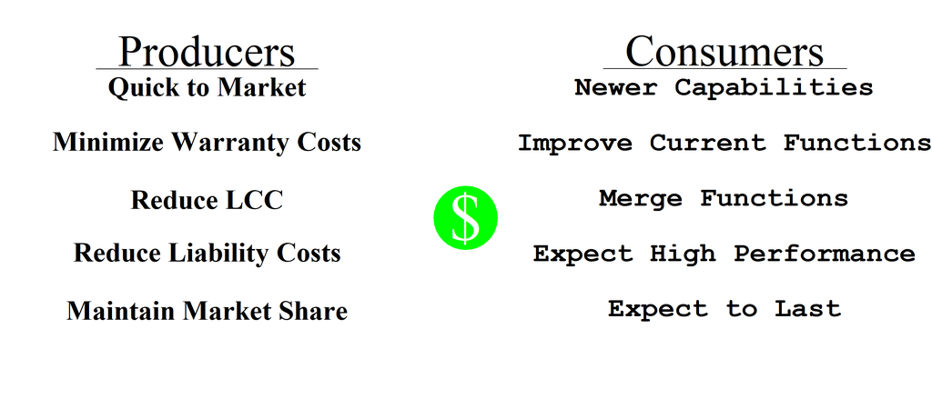

```r
par(mar = c(0,0,0,0))
plot(NA,
     xlim = range(0,500),
     ylim = range(25,525),
     axes = FALSE,
     xlab = '',
     ylab = '')

points(x = 250,
       y = 250,
       col = 'green',
       cex = 13,
       lwd = 4,
       pch = 16)

text(x = c(100,250,400),
     y = c(475,250,475),
     labels = c(expression(underline('  Producers  ')),
                '$',
                expression(underline('  Consumers  '))),
     cex = c(4, 6, 4),
     font = 2,
     col = c(1, 0, 1))

text(x = rep(100, 5),
     y = seq(425, 75, -75),
     labels = c('Quick to Market',
                'Minimize Warranty Costs',
                'Reduce LCC',
                'Reduce Liability Costs',
                'Maintain Market Share'),
     cex = rep(2.5, 5),
     family = 'serif')

text(x = rep(400, 5),
     y = seq(425, 75, -75),
     labels = c('Newer Capabilities',
                'Improve Current Functions',
                'Merge Functions',
                'Expect High Performance',
                'Expect to Last'),
     cex = rep(2.5,5),
     family = 'mono')
```

## The EXTENDED product reliability environment

- Scientists
  - Develop improved materials that can enable new capabilities
  - Find more efficient system architectures
- Governments
  - Issue new safety requirements (for products and employees)
  - Create new environmental regulations
- Competitors
  - Develop newer/better/cheaper products that can impact your profit margins
  - Competition to get your product to market first
- Test experts
  - Develop new test capabilities to find and remove failures
  - Derive new analysis techniques to reduce test time or number of samples

# 1.1.2 - Reasons For Collecting Reliability Data

## Why should reliability data be collected?

- Assess performance characteristics of materials over design life
- Predict product reliability
- Assess the effect of a proposed design change
- Compare components from different manufacturers
- Assess product reliability in field
- Checking the veracity of an advertising claim
- Track new failure modes
- Predict product warranty costs
- Ensure safety requirements are met

# 1.1.3 - Distinguishing Features of Reliability Data

- Reliability data structures can be very complex (closed form solutions rarely exist)
- Software required to solve all but the most basic problems (this class will use R)
- Data are typically censored
- Observations (e.g., time or cycles to failure) are strictly positive
- Estimating model parameters is usually **not** the primary interest
- Extrapolation is often required when applying accelerated stresses

# EXAMPLES OF RELIABILITY DATA

- This section lists several real-world examples of reliability data sets
- Demonstrates the wide range of reliability data structures
  - Right, left, and interval censoring
  - Multiple failure modes
  - Different usage measures (time, flight hours, miles driven, rounds fired)
  - Explanatory variables (accelerated stresses, differing usage environments)

# 1.2.1 - Failure Data (No Explanatory Variables)

## Explanatory variables

- Explanatory variables are commonly used in regression modeling or design of experiments
  - May be called regressors or experimental factors in certain contexts
  - Used to reduce uncertainty in responses by incorporating differences in how units were tested
- In the context of reliability, explanatory variables can be used to define the severity of an environment to which a system was exposed
  - The severity of the environment relates how quickly a product's "life" is consumed
  - If it can be reasonably assumed that each unit was exposed to an equivalent environment, explanatory variables may be ignored and the failure observations $t_i, i=1,2,...$ are assumed to be $iid$
  - Assuming $t_{i} \sim iid, \forall i$ implies that any differences in the sample population or test process are captured by $Var[X]$
- Reasons why modeling time-to-event data can produce poor results
  - Inappropriate time-scale used to measure operating life (e.g. specifying the lifetime of landing gear components in flight hours instead of take-off/landing cycles)
  - Not considering the severity of the operating environment

# 1.2.1 - Failure Data (No Explanatory Variables) - Example 1.1

## Example 1.1 - Ball Bearing Fatigue Test (Liebling & Zelen, 1956)

- Motivation for the study
  - Fatigue is known to affect the service life of deep-groove ball bearings
  - Applying higher levels of stress further reduces the fatigue life of the ball bearings
  - A failure time regression model was developed to describe the effect that higher levels of stress have on the fatigue life of these bearings.
  - However, there was disagreement within the industry on whether the estimated parameter values currently being used were accurate.
  - Additional testing was required to reduce the uncertainty about the parameter values used in the model.
- Study objectives
  - Test several ball bearings at a key stress level to augment the existing failure data
  - The additional observations should result in better estimates of the parameter values used to model fatigue life as a function of the applied stress in deep-groove ball bearings
- Data Set (Table 1.1) `lzbearing`
  - The data are the number of accumulated fatigue cycles observed when each failure occurred
  - The data are reported in millions of cycles for $n = 23$ bearings
  - We aren't told what stress was applied to each bearing in this test
  - We must assume that the stress applied to all 23 bearings was equivalent
- Analysis
  - A full analysis would include the data observed at every stress level to determine the conditional failure-time distributions
  - In this simplified case, an analysis would entail fitting the data to a single distribution using graphical methods (histograms, event plots) and numerical methods (maximum likelihood)

```r
library(SMRD)
library(DT)

DT::datatable(SMRD::lzbearing)
```

|  | megacycles |
| --- | --- |
| 1 | 17.88 |
| 2 | 28.92 |
| 3 | 33 |
| 4 | 41.52 |
| 5 | 42.12 |
| 6 | 45.6 |
| 7 | 48.4 |
| 8 | 51.84 |
| 9 | 51.96 |
| 10 | 54.12 |

[output cut: 13 more lines]

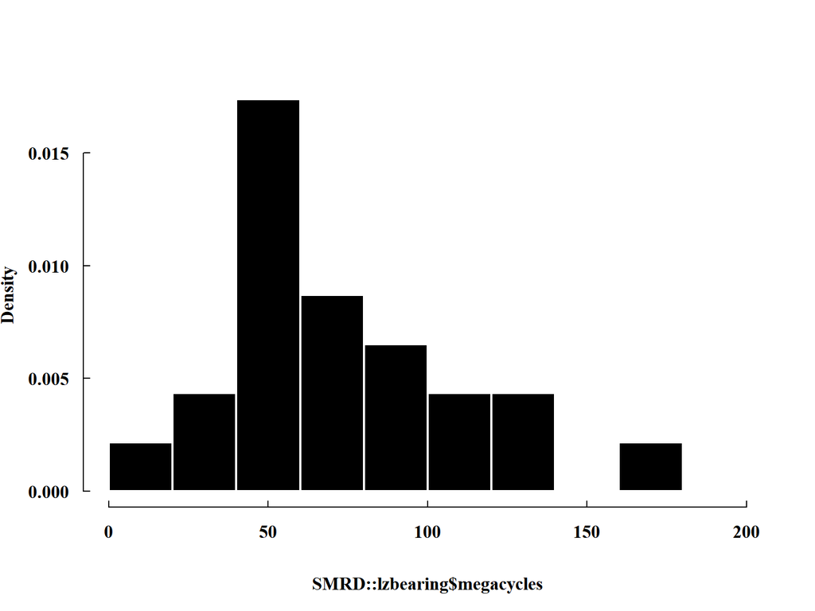

Figure 1.1 - Histogram of the ball bearing failure data

```r
library(SMRD)

par(family = 'serif', font = 2)

hist(SMRD::lzbearing$megacycles,
     breaks = seq(0,200,20),
     col = 'black',
     border = 'white',
     prob = TRUE,
     main = '',
     las = 1)
```

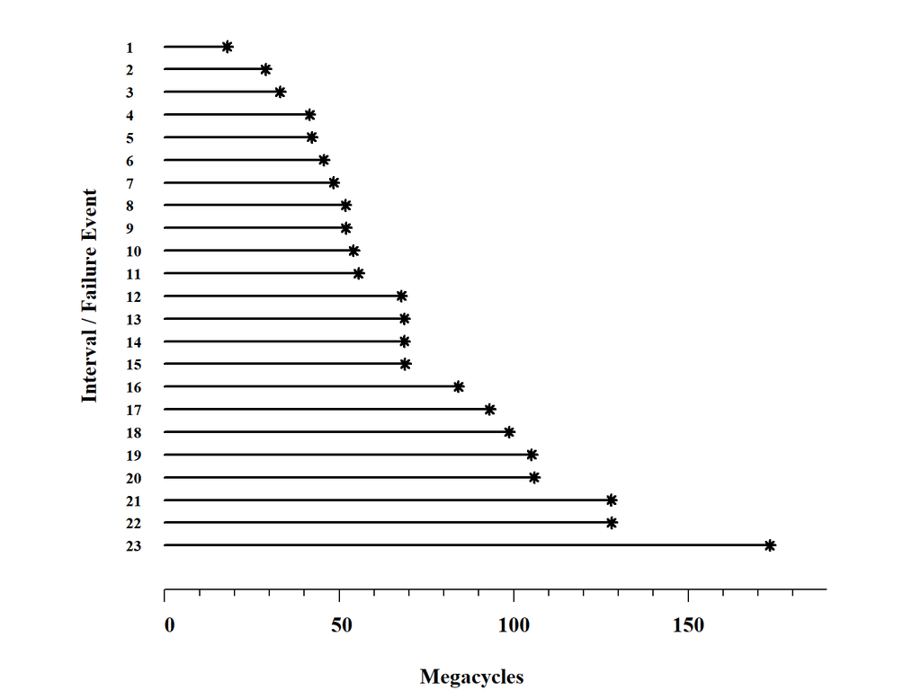

Figure 1.2 - Event plot of the ball bearing failure data

```r
library(SMRD)

par(family='serif', font=2)

lzbearing.ld <- frame.to.ld(SMRD::lzbearing,
                            response.column = 1,
                            time.units = 'Megacycles')

event.plot(lzbearing.ld)
```

# 1.2.1 - Failure Data (No Explanatory Variables) - Example 1.2

## Example 1.2 - Integrated Circuit Life Test (Meeker, 1987)

- Motivation for the study
  - Company A is shipping products with defective integrated circuits (IC)
  - The company wants to identify which units contain defective IC's and remove them from the population of items to be shipped
  - Identifying the defective products requires testing them to simulate their first year of operation (a process called burn-in)
  - Very little time is available to conduct the burn-in inspection
  - Temperature and humidity are known to affect the service life of IC's
  - Exposing the units to elevated temperature and humidity may help speed the burn-in inspection
  - However, the company is concerned that this 'accelerated' burn-in may not produce meaningful information
- Study objectives
  - Estimate the probability of IC's failing before 100 hours
  - Estimate the hazard function at 100 hours
  - Estimate the required burn-in time to remove the majority of the defective units
- Data set (Table 1.2) `lfp1370`
  - Lifetimes of $n = 4156$ integrated circuits (IC's)
  - IC's were exposed to $80^{o}C$ and $80\%$ relative humidity until failure
  - The test was stopped after 1370 hours
- Analysis
  - Of the $4156$ units tested, only 28 failures were observed
  - The failure times for the remaining units are unknown, but would have been observed at some point if testing had continued - there are known as right-censored observations.
  - This analysis entails fitting the data to a probability distribution using maximum likelihood techniques adapted to include right-censored data.

```r
library(SMRD)
library(DT)

DT::datatable(SMRD::lfp1370)
```

|  | hours | event | count |
| --- | --- | --- | --- |
| 1 | 0.1 | Failure | 2 |
| 2 | 0.15 | Failure | 1 |
| 3 | 0.6 | Failure | 1 |
| 4 | 0.8 | Failure | 2 |
| 5 | 1.2 | Failure | 1 |
| 6 | 2.5 | Failure | 1 |
| 7 | 3 | Failure | 1 |
| 8 | 4 | Failure | 2 |
| 9 | 6 | Failure | 1 |
| 10 | 10 | Failure | 2 |

[output cut: 12 more lines]

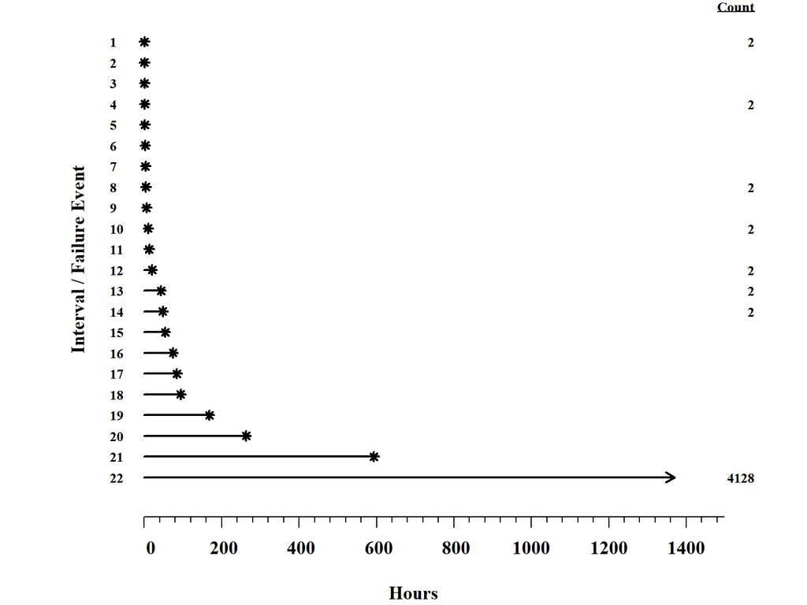

Figure 1.3 - Event plot for the lfp1370 failure data

```r
library(SMRD)

par(family = 'serif',font = 2,bg = NA)

IC.ld <- SMRD::frame.to.ld(frame = lfp1370,
                           response.column = 1,
                           censor.column = 2,
                           case.weight.column = 3,
                           time.units = 'Hours')

event.plot(IC.ld)
```

# 1.2.1 - Failure Data (No Explanatory Variables) - Example 1.5

## Example 1.5 - Heat Exchanger Tube Crack Data (Meeker & Escobar, 1996)

- Motivation for the study
  - Nuclear power plants use heat exchangers to transfer energy from the reactor to the steam turbines
  - Heat exchangers can contain several thousand tubes to transfer the steam
  - As result of continuous exposure to steam and pressure, the tubes can develop cracks over time
  - If the cracks grow large enough, a catastrophic failure could occur
  - Tubes are periodically inspected (nondestructive) for cracks
  - If a crack is found in a tube, that tube is sealed off with concrete and is no longer used
  - Once a certain number of tubes have been sealed, the entire heat exchanger must be replaced
- Study objectives
  - Engineers what to estimate the service life of the tubes at three nuclear power plants
  - Only a sample of the tubes at each nuclear power plant (100) can be inspected
- Data set `heatexchanger`
  - The data are inspection results from 300 heat exchanger tubes, inspected at each of the three geographically separated plants
  - If the data from all three plants could be combined, a more accurate estimate of the the service life might be determined
  - However, the data can only be combined if the tubes were produced in a similar manufacturing process and were used under similar conditions
  - Figure 1.6 shows the raw, un-combined data
  - Figure 1.7 shows the combined data
  - The observations are left, right, and interval censored since each plant began operating one year apart
- Analysis
  - Of the 300 tubes inspected, 11 were found to have cracks of sufficient length to be sealed off.
  - In the combined data set all 300 tubes experienced the first year of operation, 200 tubes experienced the first two years of operation, and only 100 tubes experienced all three years of operation.
  - This analysis entails fitting the data to a probability distribution using maximum likelihood techniques adapted to include left, right, and interval-censored data.

```r
library(SMRD)
library(DT)

DT::datatable(SMRD::heatexchanger)
```

|  | lower | upper | event | count | plant |
| --- | --- | --- | --- | --- | --- |
| 1 | 1 | 1 | Left | 1 | Plant1 |
| 2 | 1 | 2 | Interval | 2 | Plant1 |
| 3 | 2 | 3 | Interval | 2 | Plant1 |
| 4 | 3 | 3 | Right | 95 | Plant1 |
| 5 | 1 | 1 | Left | 2 | Plant2 |
| 6 | 1 | 2 | Interval | 3 | Plant2 |
| 7 | 2 | 2 | Right | 95 | Plant2 |
| 8 | 1 | 1 | Left | 1 | Plant3 |
| 9 | 1 | 1 | Right | 99 | Plant3 |

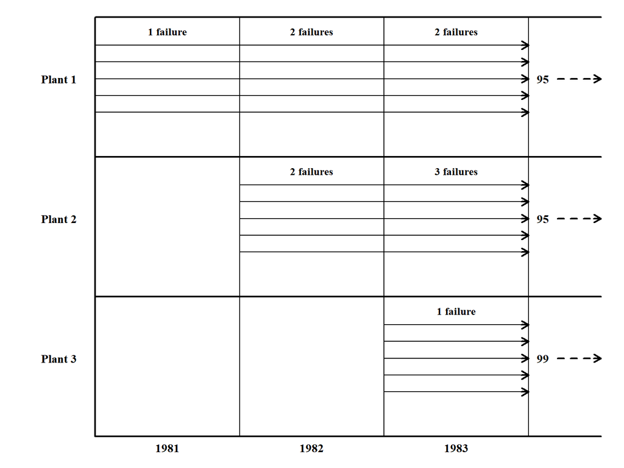

Figure 1.6 - Diagram of the raw heatexchanger data

```r
par(family = 'serif',font = 2, mar = c(0,0,0,0))

plot(NA,
     axes = FALSE,
     xlab = '',
     ylab = '',
     xlim = range(-50,350),
     ylim = range(-10,300))

segments( x0 = c(0,0,0,0,0,rep(0,5),rep(100,5),rep(200,5),100,200,300),
          y0 = c(0,100,200,300,0,seq(232,280,12),seq(132,180,12),seq(32,80,12),0,0,0),
          x1 = c(350,350,350,350,0,rep(300,15),100,200,300),
          y1 = c(0,100,200,300,300,seq(232,280,12),seq(132,180,12),seq(32,80,12),300,300,300),
          lwd = c(rep(2,5), rep(1,18)))

text(x = rep(-25,3),
     y = seq(56,256,100),
     labels = c('Plant 3',
                'Plant 2',
                'Plant 1'),
     cex = rep(0.9,3))

text(x = c(50,rep(150,2),rep(250,3)),
     y = c(rep(290,2),190,290,190,90),
     labels = c('1 failure',
                '2 failures',
                '2 failures',
                '2 failures',
                '3 failures',
                '1 failure'),
     cex = rep(0.8,6))

text(x = seq(50,250,100),
     y = rep(-8,3),
     labels = c('1981',
                '1982',
                '1983'),
     cex = rep(0.9,3))

text(x = rep(310,3),
     y = seq(56,256,100),
     labels = c('99','95','95'),
     cex = rep(0.9,3))

segments(x0 = rep(320,3),
         y0 = seq(56,256,100),
         x1 = rep(345,3),
         y1 = seq(56,256,100),
         lty = rep(2,3))

arrows(x0 = rep(295,15),
       y0 = c(seq(232,280,12),seq(132,180,12),seq(32,80,12)),
       rep(300,15),
       length = rep(0.1,15))

arrows(x0 = rep(345,3),
       y0 = seq(56,256,100),
       x1 = rep(350,3),
       length = rep(0.1,3))
```

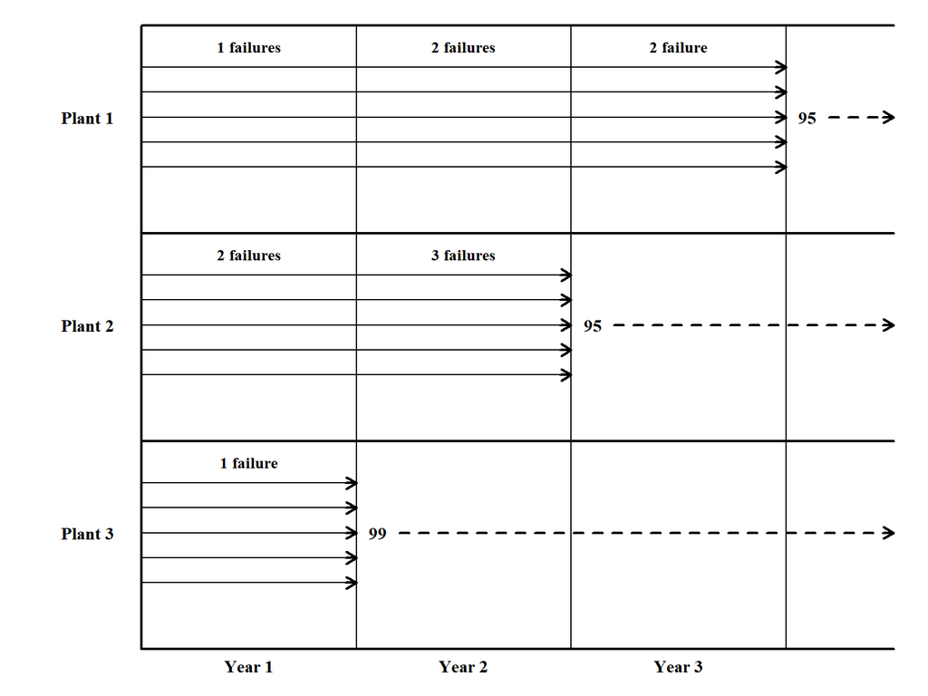

Figure 1.7 - Diagram of the transformed heatexchanger data

```r
par(family = 'serif',font = 2,mar = c(0,0,0,0))

plot(NA,
     axes = FALSE,
     xlab = '',
     ylab = '',
     xlim = range(-50,350),
     ylim = range(-10,300))

segments( x0 = c(0,0,0,0,0,rep(0,15),100,200,300),
          y0 = c(0,100,200,300,0,seq(232,280,12),seq(132,180,12),seq(32,80,12),0,0,0),
          x1 = c(350,350,350,350,0,rep(300,5),rep(200,5),rep(100,5),100,200,300),
          y1 = c(0,100,200,300,300,seq(232,280,12),seq(132,180,12),seq(32,80,12),300,300,300),
          lwd = c(rep(2,5),rep(1,18)))

text(x = rep(-25,3),
     y = seq(56,256,100),
     c('Plant 3','Plant 2','Plant 1'),
     cex=rep(0.9,3))

text(x = c(rep(50,3),rep(150,2),250),
     y = c(90,190,290,190,rep(290,2)),
     labels = c('1 failure',
                '2 failures',
                '1 failures',
                '3 failures',
                '2 failures',
                '2 failure'),
     cex = rep(0.8,6))

text(x = seq(50,250,100),
     y = rep(-8,3),
     labels = c('Year 1',
                'Year 2',
                'Year 3'),
     cex = rep(0.9,3))

text(x = c(110,210,310),
     y = seq(56,256,100),
     labels = c('99',
                '95',
                '95'),
     cex = rep(0.9,3))

segments(x0 = c(120,220,320),
         y0 = seq(56,256,100),
         x1 = c(345,345,345),
         y1 = seq(56,256,100),
         lty = rep(2,3))

arrows(x0 = c(rep(295,5),rep(195,5),rep(95,5)),
       y0 = c(seq(232,280,12),seq(132,180,12),seq(32,80,12)),
       x1 = c(rep(300,5),rep(200,5),rep(100,5)),
       length = rep(0.1,15))

arrows(x0 = rep(345,3),
       y0 = seq(56,256,100),
       x1 = rep(350,3),
       length = rep(0.1,3))
```

# 1.2.2 - Failure Data (w/ Explanatory Variables)

## Analyzing data with explanatory variables

- Often, units are tested at multiple environments with differing levels of severity
  - To drive failures more quickly
  - To reduce the overall test time
- Recall, explanatory variables can be used to relate how quickly "life" is consumed in each environment
- Changing the value of an explanatory variable changes the value of one or more parameters in the underlying failure distribution (think regression)
- Complex models are often required to compare life consumption rates between severity levels
- Examples
  - Cracks grow faster when a higher level of stress is applied
  - Tire treads wear faster when driven on gravel roads
  - Metal corrodes faster when it is exposed to humid environments
- It is critical that the results observed at higher stress environments represent the behavior observed at the use-level stress
  - We could subject a test unit to a temperature that would cause some component to melt, but that would not give any useful information about the time to failure out in the field
  - We can generate failures very quickly - even instantly in some cases
  - But, the desire to reduce the total test time should not cause failures that would never be observed in the operating environment

# 1.2.2 - Failure Data (w/ Explanatory Variables) - Example 1.8

## Example 1.8 - Printed Circuit Board ALT Data (Meeker & LuValle, 1995)

```r
library(SMRD)
library(DT)

DT::datatable(SMRD::printedcircuitboard)
```

|  | lower | upper | count | event | rh |
| --- | --- | --- | --- | --- | --- |
| 1 | 14 | 18 | 1 | 3 | 82.4 |
| 2 | 18 | 22 | 1 | 3 | 82.4 |
| 3 | 30 | 34 | 8 | 3 | 82.4 |
| 4 | 42 | 46 | 3 | 3 | 82.4 |
| 5 | 46 | 50 | 3 | 3 | 82.4 |
| 6 | 50 | 54 | 3 | 3 | 82.4 |
| 7 | 58 | 62 | 4 | 3 | 82.4 |
| 8 | 62 | 66 | 1 | 3 | 82.4 |
| 9 | 66 | 70 | 5 | 3 | 82.4 |
| 10 | 70 | 74 | 2 | 3 | 82.4 |

[output cut: 130 more lines]

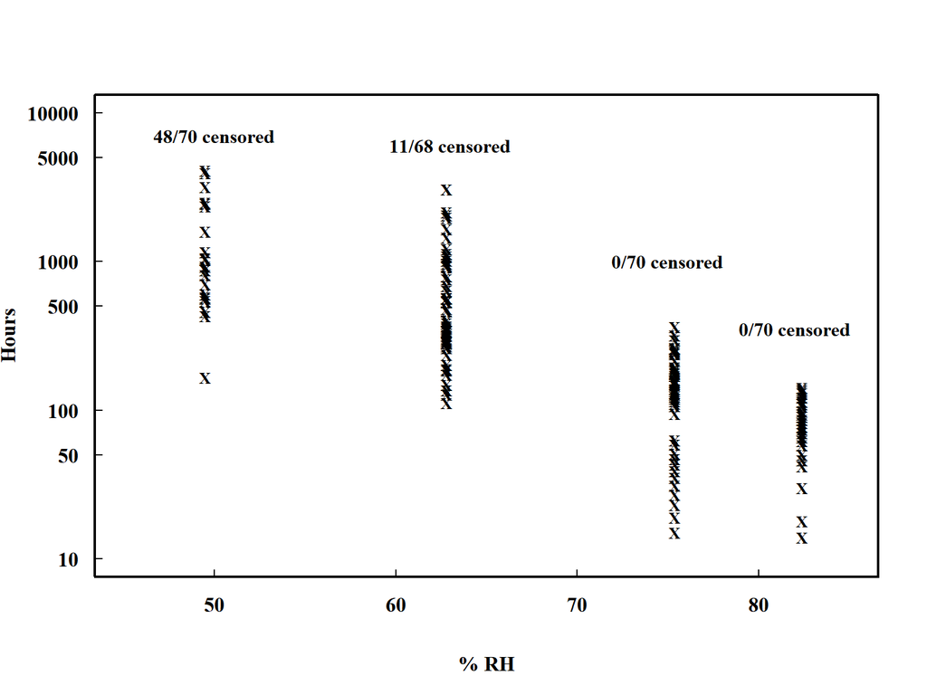

Figure 1.9 - Scatter plot of the printedcircuitboard failure data at four different stress levels

```r
par(family = 'serif', font = 2)

plot(lower~rh,
     data = SMRD::printedcircuitboard,
     pch = 'X',
     cex = .85,
     log = 'y',
     ylim = c(10,10000),
     xlim = c(45,85),
     las = 1,
     ylab = 'Hours',
     xlab = "% RH")

text(x = c(50,63,75,82),
     y = c(7000,6000,1000,350),
     labels = c('48/70 censored',
              '11/68 censored',
              '0/70 censored',
              '0/70 censored'))
```

# 1.2.3 - Degradation Data (No Explanatory Variables)

## Degradation failures

- Occur when the value of a system performance measure crosses above or below a critical value
- Soft degradation failures: - Occurs when a performance measure crosses an acceptable level
  - Power window motor raises/lowers windows too slowly
  - Tire tread depth falls below a safe level
- Hard degradation failure: - Occurs when a physical measure crosses a failure level
  - Power window motor gear teeth thickness wears down to where it fails
  - Tire wear becomes so extreme that the tire fails below

# 1.3.1 - Define The Target Population Or Process

## Enumerative studies

- Used to ASSESS the performance of MATURE products
- Most statistics courses discuss enumerative studies
- Test a random sample from a population of units
- Observe test results, analyze data, and make conclusions
- BUT, what if your conclusion is these parts suck and don't meet the reliability requirement?

## Analytic Studies

- Used to IMPROVE the performance of IMMATURE products
- Most reliability tests are Analytic Studies
- You improve the design, and now...
- Your test data is based on a prior design that doesn't exist anymore

# 1.3.2 - Causes of Failure and Degradation Leading To Failure

## Most failures result from physical degradation

- Failure results when a flaw is exposed to a severe environment for a sufficient period of time.
  - Flaws result from poor designs
  - Flaws can result from manufacturing
  - Flaws can result if the usage environment is not well understood
- The environment in which the system operates imparts stresses on the system which over time can
  - Extend microcracks
  - Loosen joints
  - Weaken electical connections
  - Magnify vibrations
  - Elevate internal temperatures
- These enlarged flaws weaken the system until the environmental stresses exceed the flaw's residual strength

```r
teachingApps::teachingApp('stress_strength')
```

# 1.3.3 - Environmental Effects Of Reliability

- It's well understood that a system's performance is affected by its operating environment
- It's less understood how many different environments a system is actually exposed to

[video not shown]

# 1.3.4 - Definition Of Time-Scale

## Most systems lifetimes can be quantified with more than one "time-scale"

- Example: A car
  - Timescale 1: Years of ownership
  - Timescale 2: Miles driven
  - Timescale 3: Number of times started
- Each customer may have their own time-scale of interest
- Each system component has a time-scale that is most appropriate

# 1.3.5 - Defining Time Origin And Failure Time

## When does a product's life begin? (This can be tricky)

- When it leaves the assembly line?
- When it ships from factory to a retailer?
- When it is purchased by a customer?
- When it is installed/unboxed?
- When it is first used?
- Is it possible to know when these events occur?

## Likewise, defining when a product's life ends can be difficult

- When the customer realizes it has stopped functioning?
- When a warranty claim is made?
- When it is received by the manufacturer?

## How we'll define time origin and failure time in this course?

- In this course defining the time origin and/or the failure time will not a be a concern
- However, you should recognize that these values must be defined prior to collecting time-to-event data for a fielded system

# 1.4 - Repairable Systems and Non-Repairable Units

## Non-repairable systems are replaced (not repaired) upon failure

- Non safety critical & inexpensive items are often non-repairable since replacement is far cheaper than repair
  - Light bulbs
  - Small appliances
  - Consumable items (filters, belts, hoses)
- Safety critical & expensive items may also be non-repairable if they must be replaced prior to failure when some degradation level is reached
  - Tires (tread depth)
  - Computers (processing speed, obsolescence)
  - Non-repairable systems may be represented by a transition diagram with one working state and one or more absorbing failure states
- The transition diagram below illustrates a nonrepairable system, where
  - State 0: Initial working state
  - States 1, 2,…: Absorbing failed states

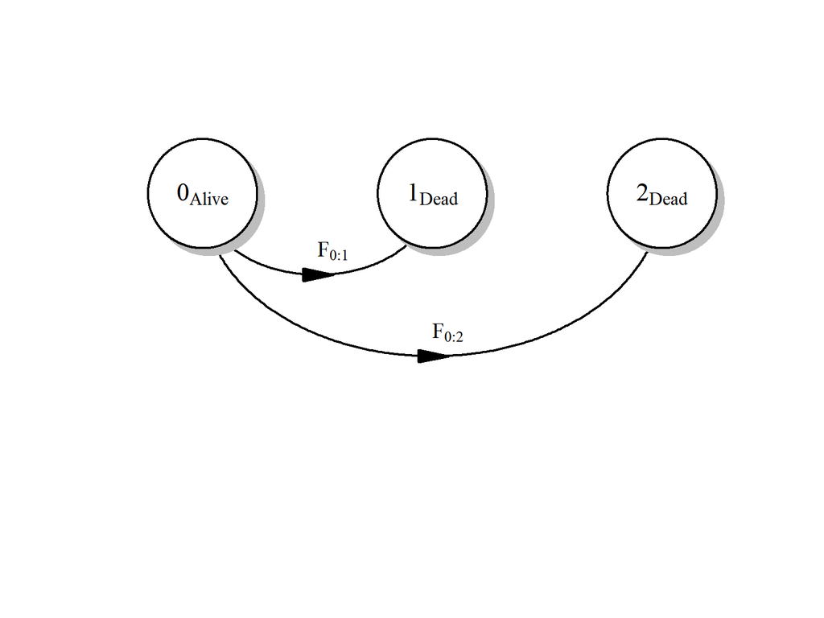

```r
Mat1 <- matrix(NA, nrow = 3, ncol = 3)

AA <- as.data.frame(Mat1)
AA[[2,1]] <- 'F[0:1]'
AA[[3,1]] <- 'F[0:2]'

name <- c(expression(0[Alive]),
          expression(1[Dead]),
          expression(2[Dead]))

par(family='serif')

diagram::plotmat(A = AA, pos = 3, curve = .575,
         name = name, lwd = 2, arr.len = 0.6,
         arr.width = 0.25, my = .25, box.size = 0.08,
         arr.type = 'triangle', dtext = -1,
         relsize=.99, box.cex=1.5, cex=1.25)
```

## Repairable systems

- Repairable systems are those that can be restored to working condition after a failure
- Repairable systems may be represented graphically by a transition diagram with one or more transient states
  - The transient states represent failure modes for which the cost of repair is far below the cost of replacement
  - As result of the repair, the system can transition back to the operating state

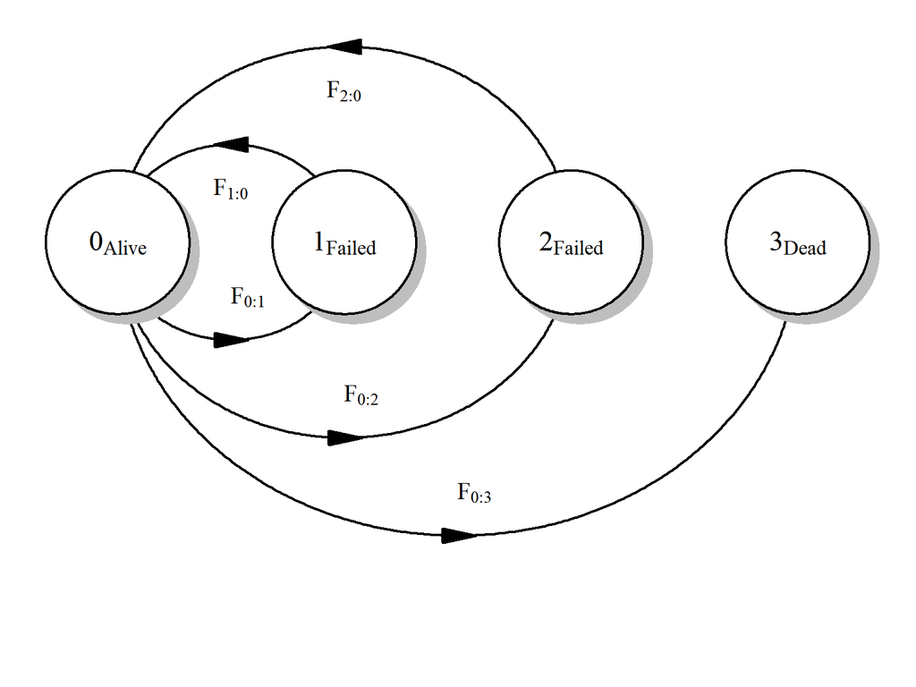

```r
library(diagram)

DiffMat <- matrix(NA, nrow = 4, ncol = 4)

AA <- as.data.frame(DiffMat)
AA[[1,2]] <- 'F[1:0]'
AA[[1,3]] <- 'F[2:0]'
AA[[2,1]] <- 'F[0:1]'
AA[[3,1]] <- 'F[0:2]'
AA[[4,1]] <- 'F[0:3]'

name <- c(expression(0[Alive]),
          expression(1[Failed]),
          expression(2[Failed]),
          expression(3[Dead]))

par(family='serif', mar = c(0,0,0,0))

diagram::plotmat(A = AA, pos = 4, curve = .575,
         name = name, lwd = 2, arr.len = 0.6,
         arr.width = 0.25, my = .15, box.size = 0.08,
         arr.type = 'triangle', dtext = -1,
         relsize=.99, box.cex=1.5, cex=1.25)
```

- Repairable systems also have one or more absrbing states
  - The absorbing states represent failure modes for which the cost of repair is equal to or greater than the cost of replacement
  - When these nonrepairable failure modes occur the system does not transition back to the operating state

# 1.5.1 - Planning A Reliability Study

## Clearly define the purpose of the current test

- Reliability tests are often campaigns composed of many disparate tests
- Each test will have its own goals
- The type(s) of test used depend on where the system is in its development
- The goal of a particular test may not sync with the overall goal of the test campaign

## Types of reliability tests

- Developmental Tests - Improve the performance of immature systems by finding & removing flaws
- Operational Tests - Assess the performance of mature systems in the operational environment

## Define the test resources available (test equip, ranges, personnel, time)

- Developmental test resources
  - Environmental test chambers
  - Performance diagnostic equipment
  - Data acquisition systems
  - Personnel - technical SME's for root cause analyses
- Operational test resources
  - Test ranges
  - Maintenance equipment
  - Personnel - operational SME's for realistic performance exercises

## Understand the environment(s) in which the fielded system will operate

- Test environments should be similar to the fielded environment
  - Ensure test results are representative of fielded operations
  - Consumers want the test environment to be more severe to ensure more failure modes are found and removed
  - Producers want the test environment to be less severe to ensure that their product successfully passes the test
- Fielded systems will be exposed to multiple-stresses, simultaneously
  - Every failure mode will respond to each stress differently
  - If a failure mode is sensitive to thermal loads, a vibration test may not produce meaningful results

## What metric(s) will be used to validate performance?

- MTBF Mean time between failures
- MTBM - Mean time between maintenance (any maintenance?)
- MTBCF - Mean time between critical failure (what is a critical failure?)
- MMH/OH - Maintenance-man hours per operational hour
- Do the data being gathered in the test support this?

## Define how precise the results should be (sample size)

- Often, data from DT cannot be used to improve the estimates in OT
- This is a very active research area

# 1.5.2 - Study For Data Analysis And Modeling

## This process will be used throughout the course to assess reliability data

1. Assess the data nonparametrically - using simple graphical methods
2. Fit one or more simple parametric models to the data
3. Check for violations of model assumptions
4. Compute model parameter estimates and confidence intervals
5. Use numeric and graphical methods to check fit to data
6. Perform sensitivity analyses on parameter values and model assumptions

# CHAPTER 1 SUMMARY

## This chapter presented:

- Examples of time-to-failure data for different types of systems
- A strategy for estimating system performance metrics from the data
- The most common reliability metric is the failure-time distribution
- Many failure time processes are modeled using a continuous scale (i.e. Time)